# Avoimen tieteen käytännöt tutkimustyössä

Open Knowledge Roadshow 2013  
Turussa, 10. lokakuuta 2013

**[Markus Kainu](http://markuskainu.fi)**  
*sosiaalipolitiikan tohtorikoulutettava*,  
[Sosiaalitieteiden laitos, Turun yliopisto](http://www.utu.fi/fi/yksikot/soc/yksikot/sosiaalitieteet/Sivut/home.aspx)  
[Aleksanteri instituutti, Helsingin yliopisto](http://helsinki.fi/aleksanteri)

# github.com/ muuankarski/ avointiede2013

- Miten julkaisen avoimesti?
- Miten avaan tutkimusdatani?
- Miksi siirtyisin käyttämään avoimia ohjelmistoja tutkimusaineistojen analysointiin?
- Mitä iloa on avoimuudesta tieteessä?
- Mitä yksittäinen tutkija voi tehdä ja missä koko tieteen teon rakenteiden tulisi muuttua?

### Sisältö

1. Avoin tiede ja avoimen tieteen koulukunnat
2. Toistettavuus avoimen tieteen käytäntönä
3. Demo: dynaamiset julkaisut avoimilla menetelmillä

# 1. Avoin tiede ja avoin tieteellinen tieto

### Avoin tiede

- Avoin tiede (open science) on kattotermi liikkeelle, joka pyrkii edistämään avoimia toimintamalleja tieteellisessä tutkimuksessa.
- Keskeinen tavoite on tutkimustulosten, tutkimusdatan ja tutkimuksessa käytettyjen menetelmien julkaiseminen avoimella lisenssillä siten, että ne ovat vapaasti kaikkien halukkaiden tarkasteltavissa sekä käytettävissä.

*Lähde: [Wikipedia: Avoin tiede](http://fi.wikipedia.org/wiki/Avoin_tiede)*

### Avoin tiede sisältää käytäntöjä, kuten

- tutkimusjulkaisujen avoimen saatavuuden (open access) edistäminen,
- tutkimusaineistojen avoin julkaiseminen (open data),
- avoimen lähdekoodin (open source) ja avoimien standardien hyödyntäminen, sekä
- tutkimusprosessin julkinen dokumentointi niin kutsutun avoimen muistikirjan menetelmällä (open notebook science)

*Lähde: [Wikipedia: Avoin tiede](http://fi.wikipedia.org/wiki/Avoin_tiede)*

### Avoinen tieteen päähyödyt

Resurssien jakamisen myötä tapahtuva:

- **tieteen kehityksen nopeutuminen**,
- tutkimuskäytäntöjen läpinäkyvyyden lisääntymisestä johtuva **laadun ja tutkimuksen toistettavuuden parantuminen**, sekä
- tutkimustulosten paremman saavutettavuuden myötä lisääntyvä **yhteiskunnallinen vaikuttavuus**
- Tutkimusaineistojen vapaa jakaminen saattaa myös lisätä viittauksia tehtyyn tutkimustyöhön

*Lähde: [Wikipedia: Avoin tiede](http://fi.wikipedia.org/wiki/Avoin_tiede)*

- Avoimesti dokumentoitu tutkimus löytyy googlesta jo varhaisessa vaiheessa, mikä voi poikia uusia yhteistyökuvioita

### Avoimen tieteen koulukunnat

| Koulukunta | Keskeinen näkemys | Mukana olevat tahot | Keskeinen tavoite | Työkalut ja metodi |
| --- | --- | --- | --- | --- |
| Yhteiskunnallinen koulukunta (public) | Tieteen tulee olla paremmin suuren yleisön saavutettavissa | Tutkijat & kansalaiset | Tehdä tiede saavutettavaksi kansalaisille | Kansalaistiede, tiedeviestintä, tiedebloggaus |
| Demokratian koulukunta (democratic) | Pääsy tietoon ei ole kaikille yhtäläinen | Tutkijat, poliitikot, kansalaiset | Tiedon avaaminen ilmaiseksi kaikille | Open access, tekijänoikeudet, avoin data, avoin koodi |
| Pragmaattinen koulukunta (pragmatic) | Yhteistyö lisäisi tieteellisen tiedon tuottaminen tehokkuutta | Tutkijat | Tiedon tuottamisen prosessien avaaminen | kollektiivinen älykkyys, verkostovaikutus, avoin data, avoin koodi |
| Infrastruktuurin koulukunta (infrastructure) | Tehokas tutkimus on riippuvainen saatavilla olevista työkaluista ja sovelluksista | Tutkijat & alustojen tuottajat | Luoda avoimia alustoja, työkaluja ja palveluita tutkijoille | Yhteistyön alustat ja työkalut |
| Vaikuttavuuden mittaamisen koulukunta (measurement) | Tieteellisten julkaisujen vaikuttavuuden mittaaminen vaatii vaihtoehtosia tapoja | Tutkijat & poliitikot | Kehittää vaihtoehtoisia mittaustapoja tieteellisen vaikuttavuuden mittaamiseen | artikkelitasoinen metriikka, vertaisarviointi, vittaaminen, vaikuttavuuskerroin |

*Lähde: [Fecher & Friesike. (2013)](http://papers.ssrn.com/sol3/papers.cfm?abstract_id=2272036), [artikkelin viitteet](https://rawgithub.com/muuankarski/avointiede2013/master/fiveschools/citations_by_schools.html)*

### Ongelmia

- edellyttää murrosta tieteentekemisen tavoissa ja kulttuurissa
- aikaa vievää, kuten suunnitelu, projektinhallinta, lisensointi
- kannustimien puute
- OA lehdet heikosti arvostettuja
- yksityisyys

*Lähde: [github.com/openscienceASAP/openscience-presentations](https://github.com/openscienceASAP/openscience-presentations/blob/master/Content.md)*

### Lisää ongelmia (eri tieteenalat)

- “tekniset hyödyt” realisoituvat laskennallisissa tieteissä
- luonnontieteiden mahdollisuudet ovat ihmistieteiden uhkia
  - Datat on arkaluonteisia
  - julkaisussa kirjojen ja perinteisten lehtien asema on kova
  - kaikessa avaamisessa nähdään varkauden riski
- monissa ihmistieteissä ei ole laskennallista “argumentaatiota”, vaan *teksti puhuu puolestaan*
  - kirjojen asema vahva
  - huoli laadukkaasta editoinnista
- ihmistieteissä usein tutkijat yksin vs. tutkimusryhmät luonnontieteissä -> riskien ottamista kartetaan
- tieteelliset seurat ja open access

### Esimerkki: Science lehti 4.10.2013

Teemanumero Science-lehdessä: [Communication in Science: Pressures and Predators](http://m.sciencemag.org/site/special/scicomm/index.xhtml) ja siinä artikkeli [Who's Afraid of Peer Review?](http://m.sciencemag.org/content/342/6154/60.full)

- keksitty juttu meni läpi monessa OA-lehdessä

**Reaktioita artikkeliin:**

- [I confess, I wrote the Arsenic DNA paper to expose flaws in peer-review at subscription based journals](http://www.michaeleisen.org/blog/?p=1439)
- [Flawed sting operation singles out open access journals](http://theconversation.com/flawed-sting-operation-singles-out-open-access-journals-18846)
- [OASPA’s response to the recent article in Science entitled “Who’s Afraid of Peer Review?”](http://oaspa.org/response-to-the-recent-article-in-science/)
- [Steve Harnan: Fair-Gold](http://mailman.ecs.soton.ac.uk/pipermail/goal/2013-October/002176.html)
- [Guardian: Open access publishing hoax: what Science magazine got wrong](http://www.theguardian.com/higher-education-network/blog/2013/oct/04/science-hoax-peer-review-open-access?CMP=twt_gu)

# 2. Toistettavuus avoimen tieteen käytäntönä

### Gradun työvirta vuodelta 2008

[figure not shown]

### Toistettava tutkimus/analyysi

(reproducible research/analysis)

- tarkoitetaan tehokasta tapaa hallita data-analyysi kokonaisuutena aina raakadatasta julkaisuvalmiiksi taulukoiksi ja kuvioiksi asti
- ensisijaisesti kyse analyysin arvioitavuudesta ja luotettavuudesta
- lisäksi toistettava data-analyysi on suoraviivaisempi, helpommin hallittava sekä ennen kaikkean jaettava

*Lähde: [Workshop: Oikopolkua datasta julkaisuun 2/2013](http://markuskainu.fi/workshop/toistettava/)*

### Toistettava tutkimus

- Analyysikoodin+datan jakaminen tiedeyhteisölle on tärkeä ja konkreettinen osa tieteellisen osaamisen ja tiedon kumuloitumista, ja merkittävä mahdollisuus juuri laskennallisten (sosiaali)tieteiden kehittymiselle
- Kun analyysissä käytetetään avoimen lähdekoodin ohjelmistoja on analyysi toistettavissa myös riippumatta tutkijan taloudellisista resursseista tai rajoittavista kaupallisten ohjelmien lisensseistä

*Lähde: [Workshop: Oikopolkua datasta julkaisuun 2/2013](http://markuskainu.fi/workshop/toistettava/)*

### Kysymys yliopistotutkijoille

*Kuinka monta it-sovellusta olet ottanut käyttöön viimeisen viiden vuoden aikana*

1. jotka palvelevat byrokratiaa?
2. jotka palvelevat tutkimuksen tekemistä?

Kuka valitsee ne analyyttiset menetelmät, joita käytämme/saamme käyttää?

### Oma ohjelmistoympäristö

- Kaikki ohjelmat vapaan ja avoimen lähdekoodin ohjelmia
- tekstien, artikkelien, webbisivujen lähdekoodit **tekstimuodossa**

**Käytän**

- [linux](http://www.linuxfoundation.org/) käyttöjärjestelmä
- [markdown](http://daringfireball.net/projects/markdown/) merkintäkieltä kirjoittamiseen (millä tahansa tekstieditorilla)
- [R-kieltä](http://www.r-project.org/) data-analyysiin, tilastolliseen analyysiin ja tilastografiikkaan
- [pandoc](http://johnmacfarlane.net/pandoc/)-dokumentinkääntäjää *lähdekooditekstin* kääntämiseen eri formaatteihin (.docx,.pdf,.ppt,.html,.epub,..)
- [.git](http://git-scm.com/)-versionhallintaa versionhallintaan

### Toistettava analyysi R-ympäristössä

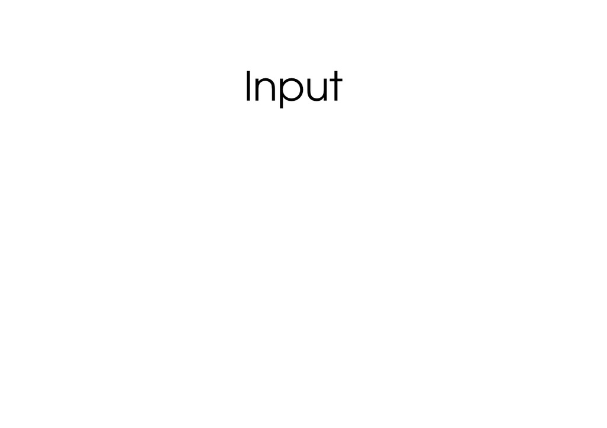

### Toistettava analyysi R-ympäristössä

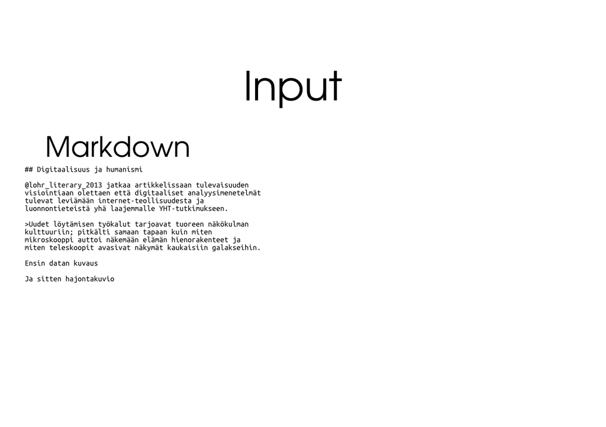

### Toistettava analyysi R-ympäristössä

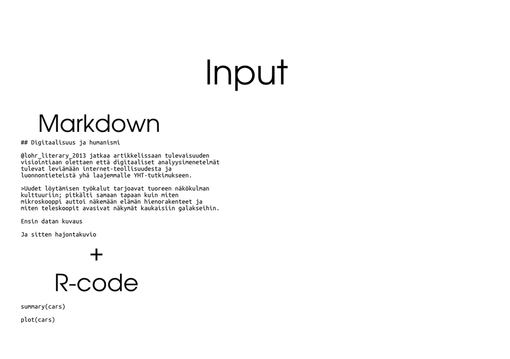

### Toistettava analyysi R-ympäristössä

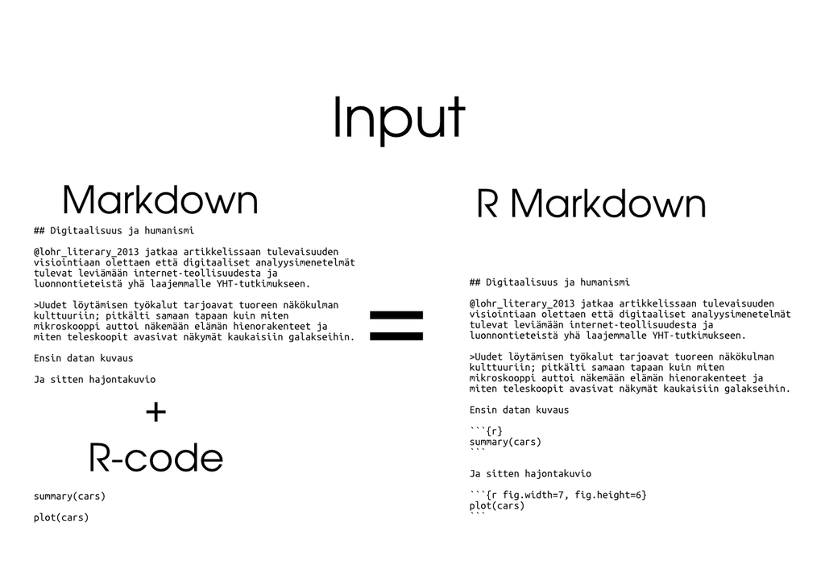

### Toistettava analyysi R-ympäristössä

[figure not shown]

### Toistettava analyysi R-ympäristössä

[figure not shown]

### Toistettava analyysi R-ympäristössä

[figure not shown]

### Toistettava analyysi R-ympäristössä

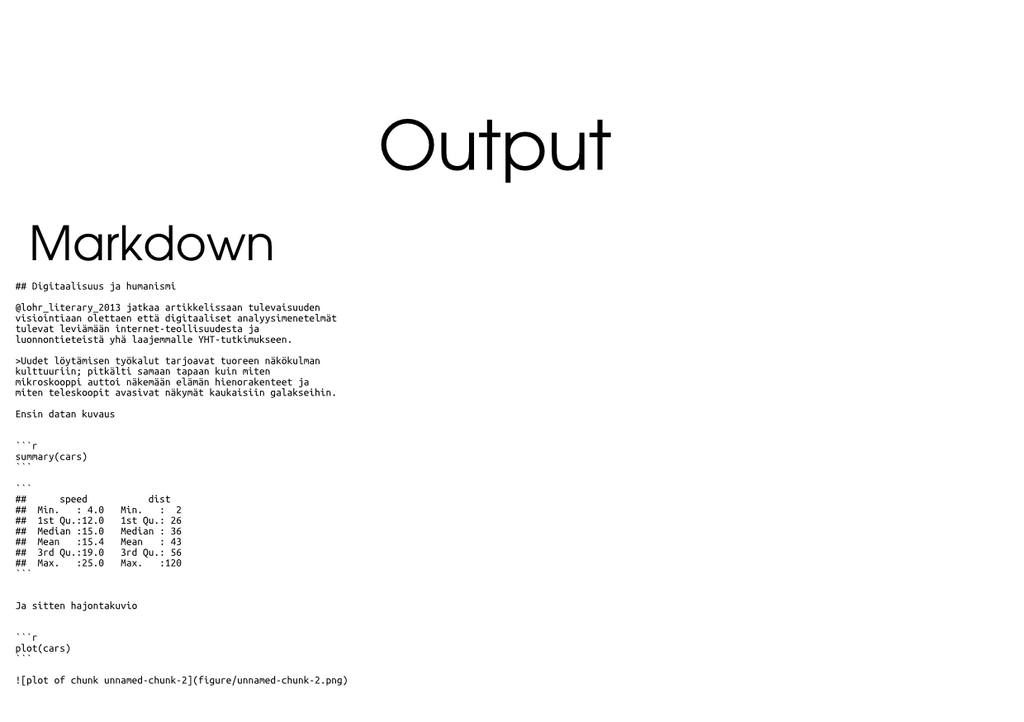

### Toistettava analyysi R-ympäristössä

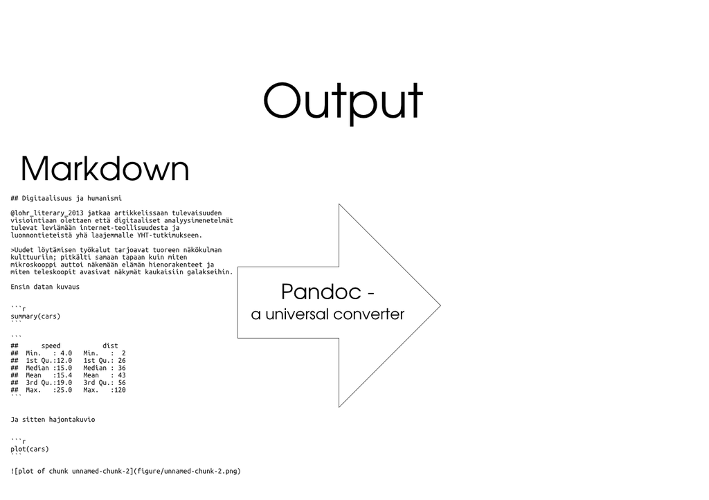

### Toistettava analyysi R-ympäristössä

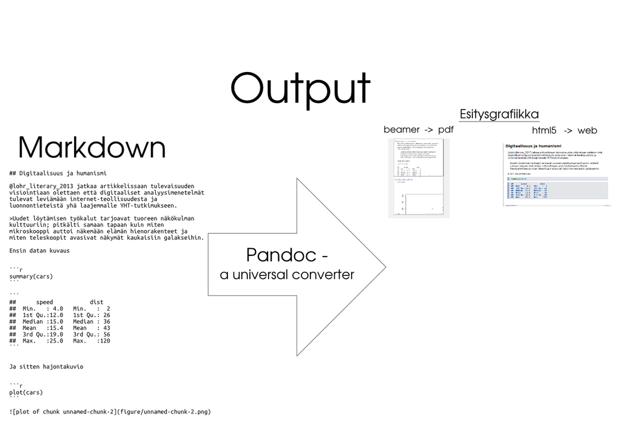

### Toistettava analyysi R-ympäristössä

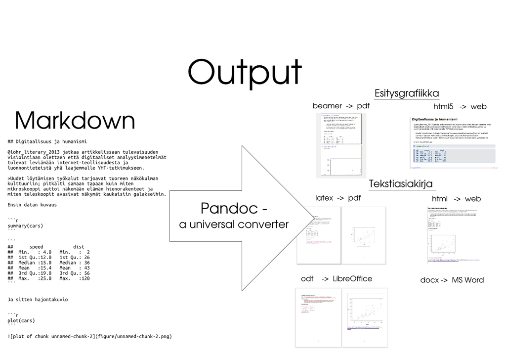

### Toistettava analyysi R-ympäristössä

- kaikkien julkaisujen *lähdekoodi* tekstimuodossa
- erityyppiset julkaisut (slaidit,raportit,artikkelit) käännetään samasta koodipohjasta
- kaikki analyysin vaiheet ohjelmoitu ja dokumentoitu

**linkkejä toistettavuudesta**

- [Treading a New Path for Reproducible Research: Part 1](http://simplystatistics.org/2013/08/21/treading-a-new-path-for-reproducible-research-part-1/)
- [Evidence-based Data Analysis: Treading a New Path for Reproducible Research (Part 2)](http://simplystatistics.org/2013/08/28/evidence-based-data-analysis-treading-a-new-path-for-reproducible-research-part-2/)

# 3. Demo: dynaamiset julkaisut avoimilla menetelmillä

### Ladataan data Google Drivesta

```r
library(RCurl)
myCsv <- getURL("https://docs.google.com/spreadsheet/pub?key=0AqQZEZLGjzKAdHlaelpHU2VDR3V1blNfeExma19keFE&output=csv")
dat <- read.csv(textConnection(myCsv), na.strings = "")
```

### Käsitellään hieman

```r
# uudet muuttujanimet
names(dat) <- c("aika","tieteenala",
        "empiriaPainot","teoriaPainot",
        "laadulPainot","dataAvointa",
        "yksinTyo","OaYleinen",
        "AtMahdollisuus","kunta")
df <- dat[-1:-11,] # pudotetaan testivastaukset pois
# aikaleimasta päivämäärä
library(stringr)
df$aika <- as.character(df$aika)
df$pvm <- str_trim(str_sub(df$aika, 1, 10))
df$pvm <- as.Date(df$pvm, format="%d.%m.%Y")
```

### Data vastaukset 1-5 ja muuttujat 7-11

```r
df[1:5,7:11]
```

```
   yksinTyo OaYleinen AtMahdollisuus        kunta        pvm
12        4         2              2        Masku 2013-10-09
13        1         3              2 Lappeenranta 2013-10-09
14        4         2              1        Turku 2013-10-10
15        1         3              2       Turku  2013-10-10
16        3         4              1         <NA> 2013-10-10
```

### Vastausten kertyminen

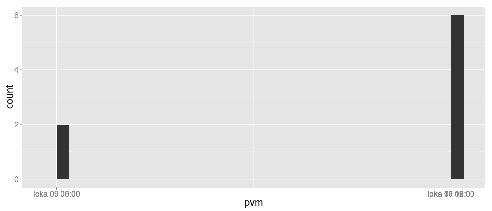

```r
library(ggplot2)
ggplot(df, aes(x=pvm)) +
  geom_bar() +
  theme_grey(base_size = 20)
```

### Tieteenala

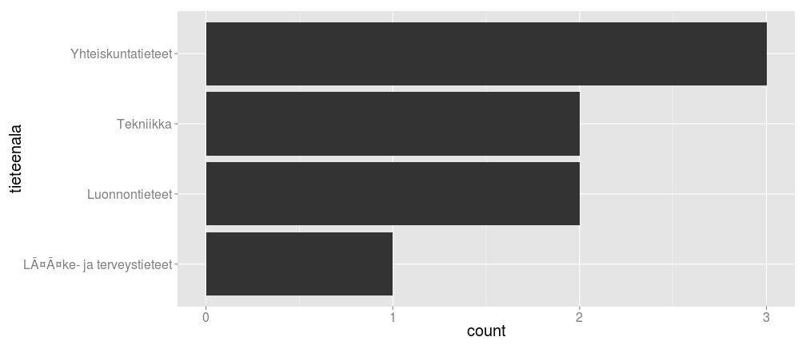

```r
library(ggplot2)
ggplot(df, aes(x=tieteenala)) +
  geom_bar() +
  coord_flip() +
  theme_grey(base_size = 20)
```

### Monivalintakysymykset

1. Voiko tutkimustasi luonnehtia empiiriseksi?
2. Voiko tutkimustasi luonnehtia teoreettiseksi?
3. Onko tutkimuksesi analyysi laadullista (vrt. määrällistä)?
4. Onko käyttämäsi aineisto avointa (vrt. salassa pidettävää)?
5. Teetkö tutkimustasi yksin (vrt. tutkimusryhmässä)?
6. Onko open access -julkaiseminen yleistä tieteenalallasi?
7. Onko avoin tiede mielestäsi mahdollisuus (vrt. uhka)?

### Vastaukset kysymyksiin

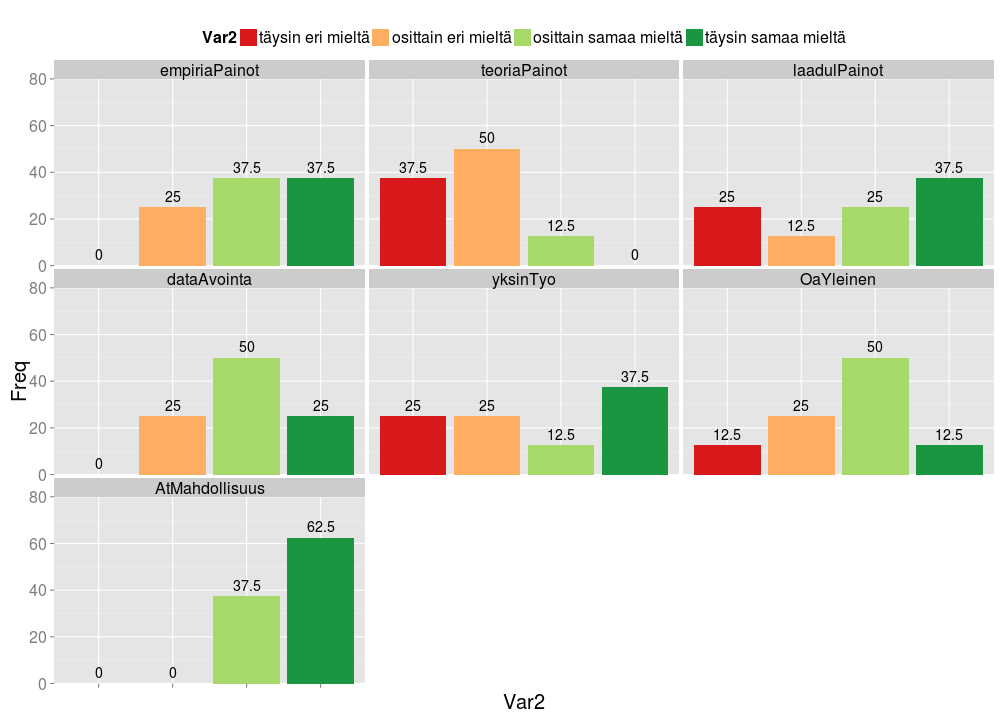

### Vastaajien synnyinpaikka

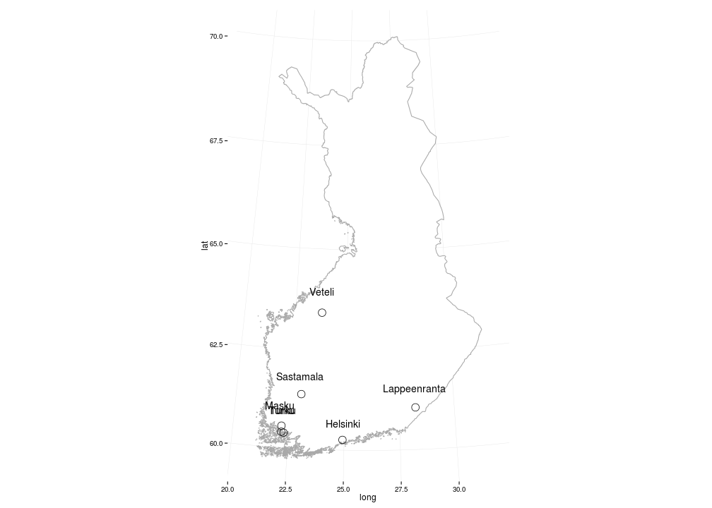

### Tekstiasiakirjat perustuen samaan koodipohjaan

```r
library(knitr)
knit("dokkari.Rmd") # into .md
system("pandoc dokkari.md -o dokkari.pdf")
system("pandoc dokkari.md -o dokkari.odt")
system("pandoc -s dokkari.md -o dokkari.html")
```

### Yhteenveto demosta

Demossa käytettiin osin avointa dataa ja avoimia menetelmiä

### avoin data

- kuntien paikkatieto googlesta (`geocoding`-funktiolla)
- Suomen paikkatietoaineisto [GADM](http://www.gadm.org/)-tietokannasta
- tutkimusdata googlen lomakkeesta (ei-avoin)

### avoimet menetelmät

- [R-laskentaympäristö](http://r-project.org)
- [Rstudio IDE](http://www.rstudio.com/ide/) -käyttöliittymä
- [knitr](http://yihui.name/knitr/) + liuta muita r-paketteja
- [pandoc](http://johnmacfarlane.net/pandoc/) - dokumentin kääntäjä

### Yhteenveto demosta

- Avoimet analyysiohjelmistot vahvoja toistettavien/dynaamisten tutkimusraporttien (paperit,esitysgrafiikka,tms.) teossa
- dynaamisuuden edut: kun data tai analyysikoodi muuttuu, niin julkaisu on aina ajan tasalla

**Linkkejä**

- [Xie (2014): Dynamic Documents with R and knitr](http://www.crcpress.com/product/isbn/9781482203530)
  - [kirjan lähdekoodi githubissa](https://github.com/yihui/knitr-book)
- [Oikopolkua datasta julkaisuun - Toistettava data-analyysiprosessi määrällisessä sosiaalitutkimuksessa R:n, Markdownin ja knitr:n avulla](http://markuskainu.fi/workshop/toistettava/)

# Kysymyksiä & kommentteja

[figure not shown]